# MALASPINA 18S amplicons analyisis

Logares R. & Rubinat-Ripoll L.

21/12/2015

# 1) Data overview

Table dimensions and content outline:

```
## MD2304 MD2332 MD2695 MD2926
##   2740   3446    425    627
```

```
## [1] 1315  119
```

```
##          MD1013 MD1035 MD1042 MD1080 MD1100
## OTU_5       162    238    486   1639    653
## OTU_1     13804   9239  37085  24192  36066
## OTU_596      20     75    100    502    118
## OTU_1295      1      1      7      1      0
## OTU_36       59    196    210    346     33
```

```r
min(colSums(otu_tb16_min5000_v2))
```

```
## [1] 5862
```

```r
max(colSums(otu_tb16_min5000_v2))
```

```
## [1] 156843
```

Identification of richest station:

```r
amplicons_per_sample<-colSums(otu_tb16_min5000_v2)
amplicons_per_sample[which(colSums(otu_tb16_min5000_v2)>156000)]
```

```
##  MD897
## 156843
```

Overall reads per sample:

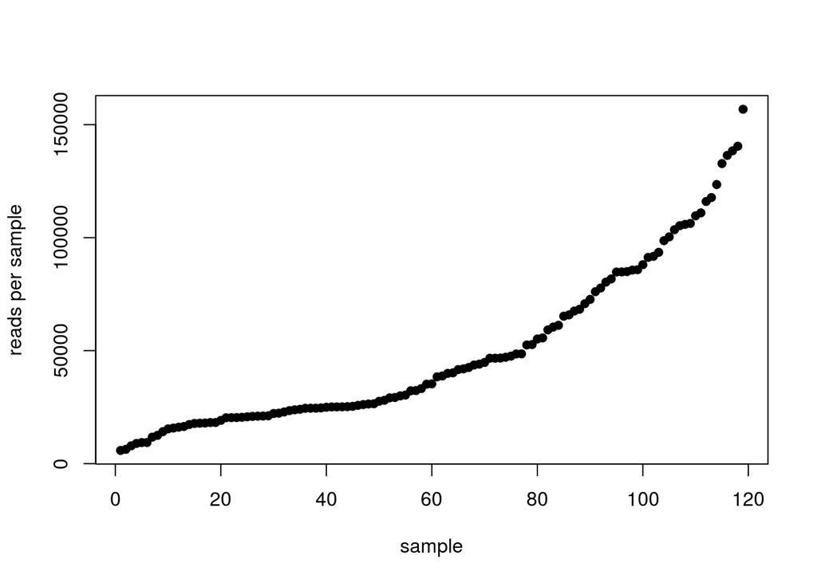

# 2) Normalization to 5000 reads per sample

Let’s normalize the original dataset by randomly subsampling 5000 reads in each station:

```r
library(vegan)
otu_tb16_min5000_v2_t<-t(otu_tb16_min5000_v2)
otu_tb16_t_ss5000<-rrarefy(otu_tb16_min5000_v2_t, 5000)
```

The normalized table shows the following dimensions and format:

```
## [1]  119 1315
```

```
##        OTU_5 OTU_1 OTU_596 OTU_1295 OTU_36
## MD1013    34  2747       2        0      8
## MD1035    45  1545      11        1     34
## MD1042    37  2645       5        0     16
## MD1080    65   940      23        0     21
## MD1100    44  2102       3        0      3
```

Its content fits on the expected normalization values (5000 reads per station):

```r
rowSums(otu_tb16_t_ss5000)
```

```
## MD1013 MD1035 MD1042 MD1080 MD1100  MD111 MD1125 MD1143 MD1176 MD1186
##   5000   5000   5000   5000   5000   5000   5000   5000   5000   5000
## MD1209 MD1222 MD1246 MD1254 MD1260 MD1293 MD1302 MD1318 MD1324 MD1331
##   5000   5000   5000   5000   5000   5000   5000   5000   5000   5000
## MD1354 MD1368 MD1398  MD141 MD1421 MD1425 MD1459 MD1475 MD1479 MD1490
##   5000   5000   5000   5000   5000   5000   5000   5000   5000   5000
## MD1517 MD1537 MD1559 MD1589 MD1607 MD1629 MD1672 MD1700 MD1724 MD1744
##   5000   5000   5000   5000   5000   5000   5000   5000   5000   5000
## MD1772 MD1798 MD1811 MD1857 MD1885 MD1887 MD1928 MD1956 MD1964  MD196
##   5000   5000   5000   5000   5000   5000   5000   5000   5000   5000
## MD2004 MD2008  MD202 MD2047 MD2051 MD2094 MD2111  MD214 MD2151 MD2155
##   5000   5000   5000   5000   5000   5000   5000   5000   5000   5000
## MD2215 MD2243 MD2247 MD2340 MD2380 MD2408 MD2436 MD2448 MD2474 MD2516
##   5000   5000   5000   5000   5000   5000   5000   5000   5000   5000
##  MD254 MD2562 MD2594 MD2624 MD2662  MD266 MD2723 MD2751 MD2761 MD2821
##   5000   5000   5000   5000   5000   5000   5000   5000   5000   5000
##  MD285 MD2864   MD28 MD2956 MD2973  MD311  MD346  MD366  MD389   MD40
##   5000   5000   5000   5000   5000   5000   5000   5000   5000   5000
##  MD417  MD439  MD458  MD486  MD506  MD528   MD52  MD550  MD575  MD591
##   5000   5000   5000   5000   5000   5000   5000   5000   5000   5000
##   MD60  MD621  MD646   MD64  MD664  MD684  MD712  MD734  MD753  MD778
##   5000   5000   5000   5000   5000   5000   5000   5000   5000   5000
##  MD806  MD834  MD854  MD876  MD897  MD916  MD940  MD962   MD98
##   5000   5000   5000   5000   5000   5000   5000   5000   5000
```

Let’s check out how many OTUs don’t appear in the new table:

```r
length(which(colSums(otu_tb16_t_ss5000)==0))
```

```
## [1] 170
```

```r
otu_tb16_t_ss5000_no_cero<-otu_tb16_t_ss5000[,-(which(colSums(otu_tb16_t_ss5000)==0))]
dim(otu_tb16_t_ss5000_no_cero)
```

```
## [1]  119 1145
```

Datasets summary:

otu_tb16_min5000_v2_t –> 119 1315

# 3) General community analysis

## 3.1) Richness and evenness (Shannon index)

Most of the samples take Shannon Index values between 2.25 and 3.25:

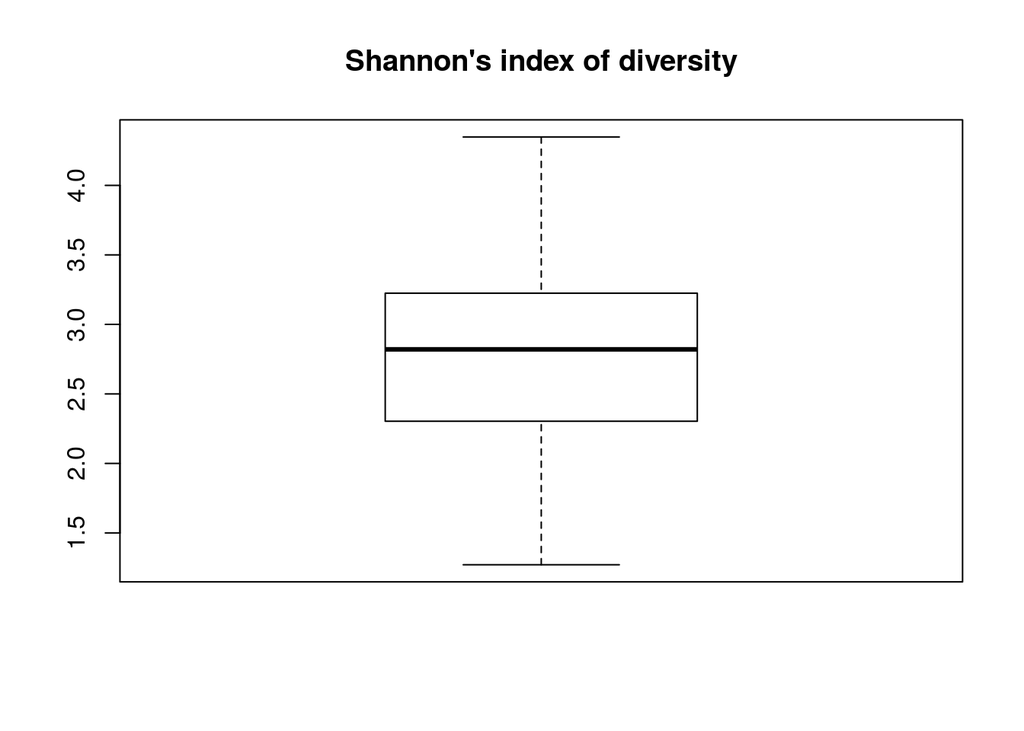

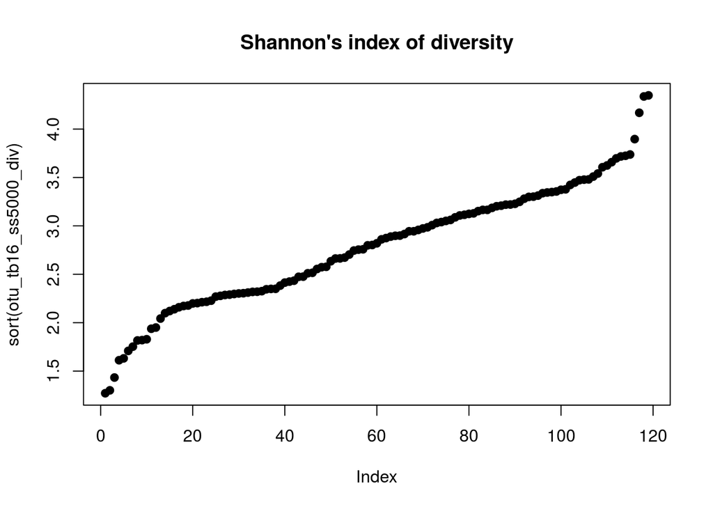

## 3.2) Richness: OTU number

Lowest number of OTUs per sample:

```
## [1] 137
```

Maximum number of OTUs per sample:

```
## [1] 379
```

In most of the samples, we can identify between 200 and 250 OTUs:

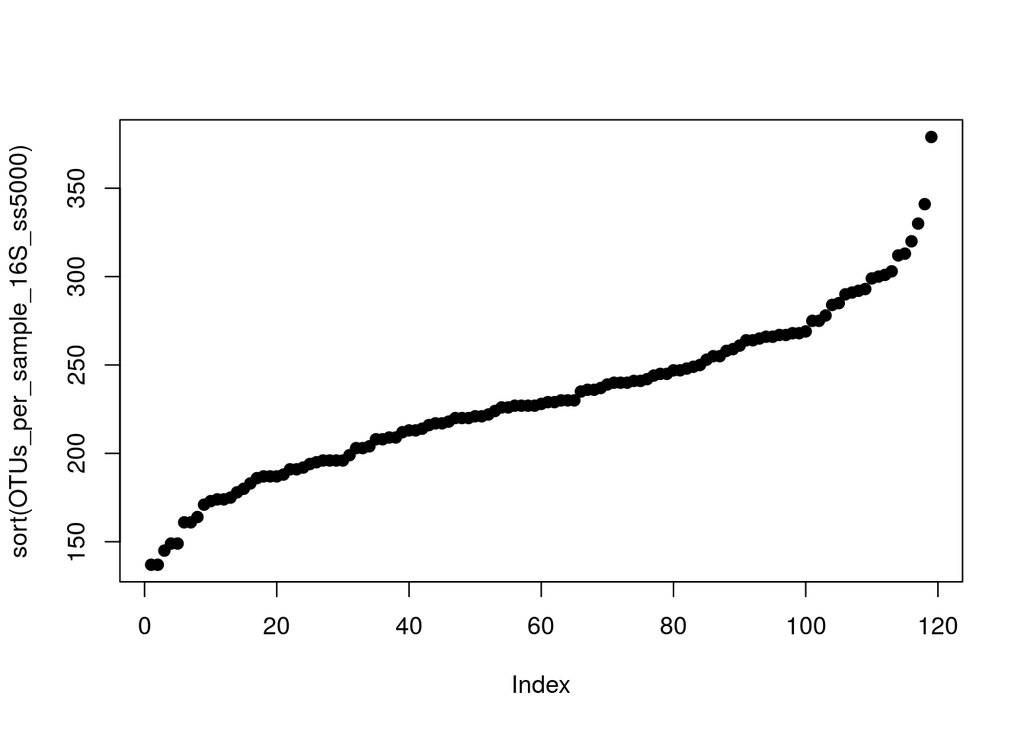

```r
plot(sort(OTUs_per_sample_16S_ss5000), pch=19)
```

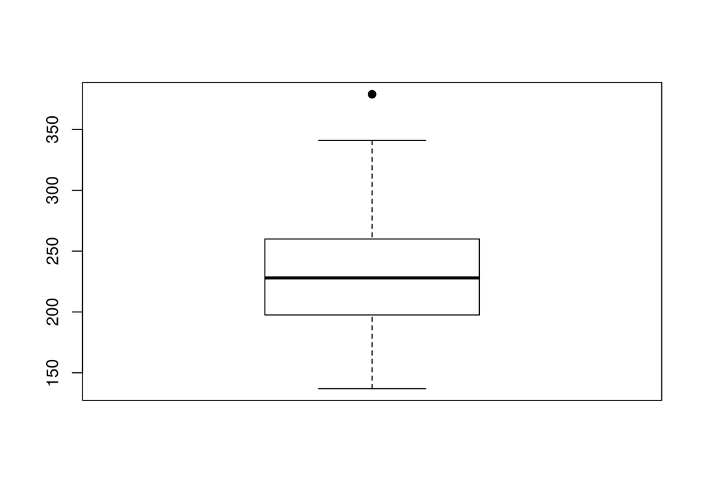

```r
boxplot(OTUs_per_sample_16S_ss5000, pch=19)
```

## 3.3) Index of evenness

### 3.3.1) Pielou’s index

```r
pielou_evenness_16S_ss5000 <- otu_tb16_ss5000_div/log(OTUs_per_sample_16S_ss5000)
```

Most of the samples get values between 0.425 and 0.6, meaning that the numerical composition of different OTUs in a sample is relatively similar:

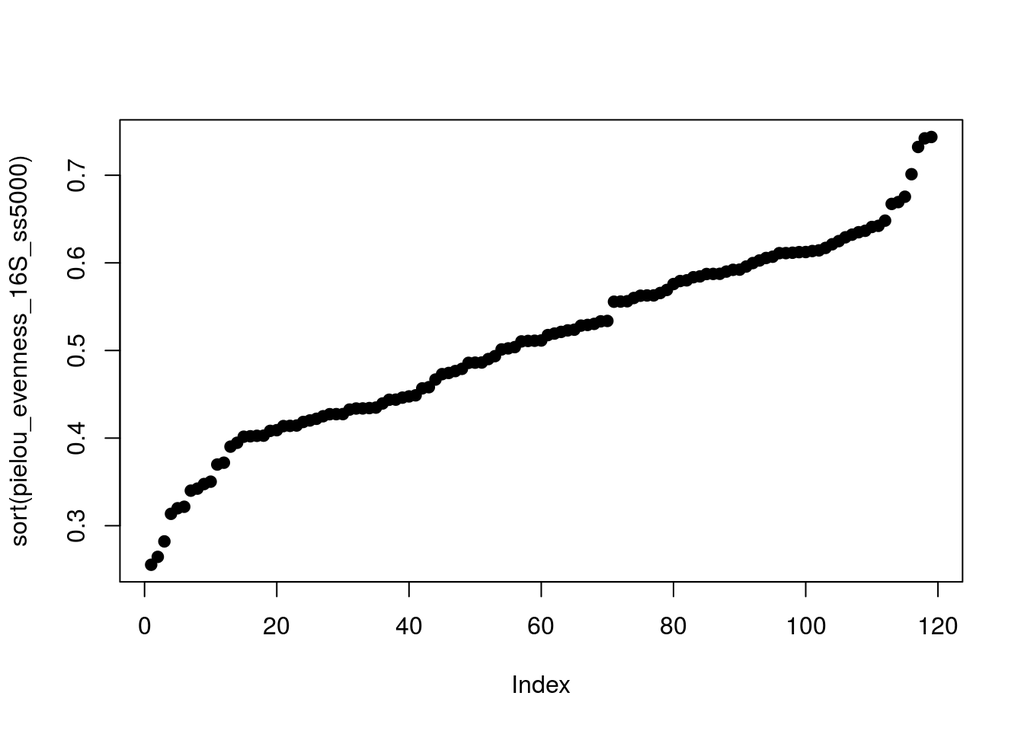

```r
plot(sort(pielou_evenness_16S_ss5000), pch=19)
```

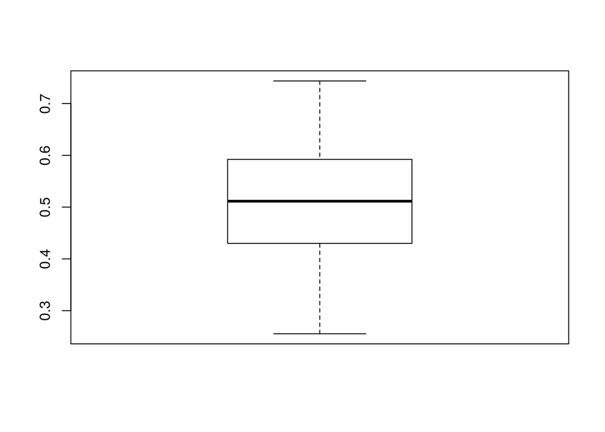

```r
boxplot(pielou_evenness_16S_ss5000, pch=19)
```

```r
head(sort(colSums(otu_tb16_t_ss5000_no_cero), decreasing=T), n=10L)
```

```
##   OTU_1   OTU_2   OTU_4   OTU_5   OTU_3   OTU_6 OTU_552  OTU_10  OTU_23
##  239152   84741   29932   23134   10560    9519    5997    5848    5375
## OTU_435
##    5364
```

Most of the OTUs show very few occurrences:

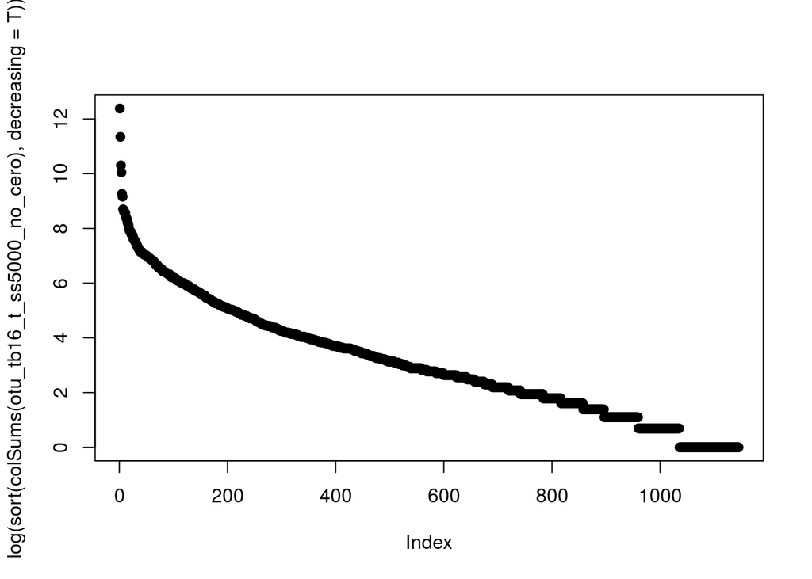

```r
plot(log(sort(colSums(otu_tb16_t_ss5000_no_cero), decreasing=T)), pch=19)
```

## 3.4) Abundance Models

### 3.4.1) Rank-Abundance or Dominance/Diversity Model (“radfit”)

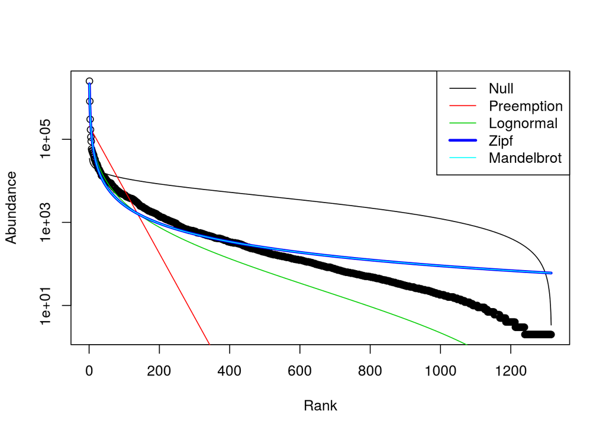

### 3.4.2) Preston’s Lognormal Model

Preston’s lognormal model fit into species frequencies groups (we’re missing ~67 species):

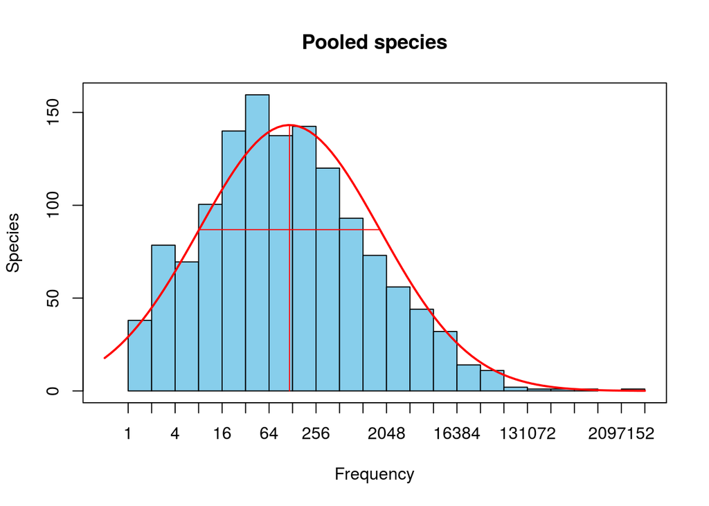

```r
otu_tb16_min5000_prestonfit<-prestonfit(colSums(otu_tb16_min5000_v2_t))
plot(otu_tb16_min5000_prestonfit, main="Pooled species")
```

```r
veiledspec(otu_tb16_min5000_prestonfit)
```

```
## Extrapolated     Observed       Veiled
##   1382.27565   1315.00000     67.27565
```

Preston’s lognormal model fit without pooling data into groups (we’re missing ~24 species):

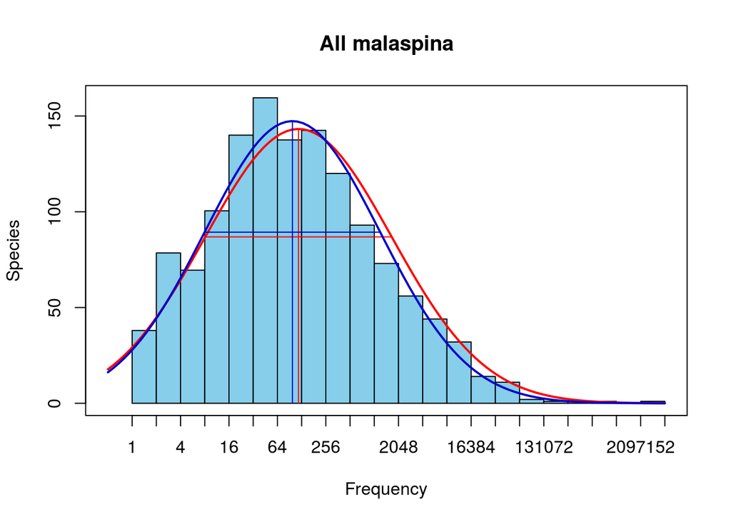

```
## Extrapolated     Observed       Veiled
##   1338.80397   1315.00000     23.80397
```

## 3.5) Rarefaction curve

```r
#?rarecurve

#str(colSums(otu_tb18_t))

#otus_tb18_colsums<-colSums(otu_tb18_t)

#str(otus_tb18_colsums)
#otu_tb18_colsums<-as.matrix(otu_tb18_colsums)

#otu_tb18_colsums<-t(otu_tb18_colsums)

#otu_tb18_colsums[,1:3]

#rarecurve(otu_tb18_colsums, step = 1, 50000, xlab = "Sample Size", ylab = "OTUs", label = TRUE)
#rarecurve(colSums(otu_tb18_t), step = 1, 50000, xlab = "Sample Size", ylab = "OTUs", label = TRUE)
```

## 3.6) Beta diversity

### 3.6.1) Dissimilarity matrix using Bray-Curtis index:

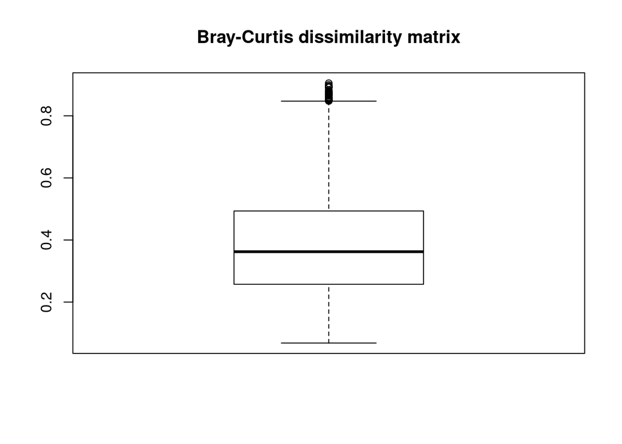

### 3.6.2) Hierarchical clustering

The only relatively evident clusters we can distinguish in the dendogram stand out in the very left side of the plot. The central cluster ranging from samples MD256 to MD2156 could also be informative. TBD: assign Longhurst provinces information to each station.

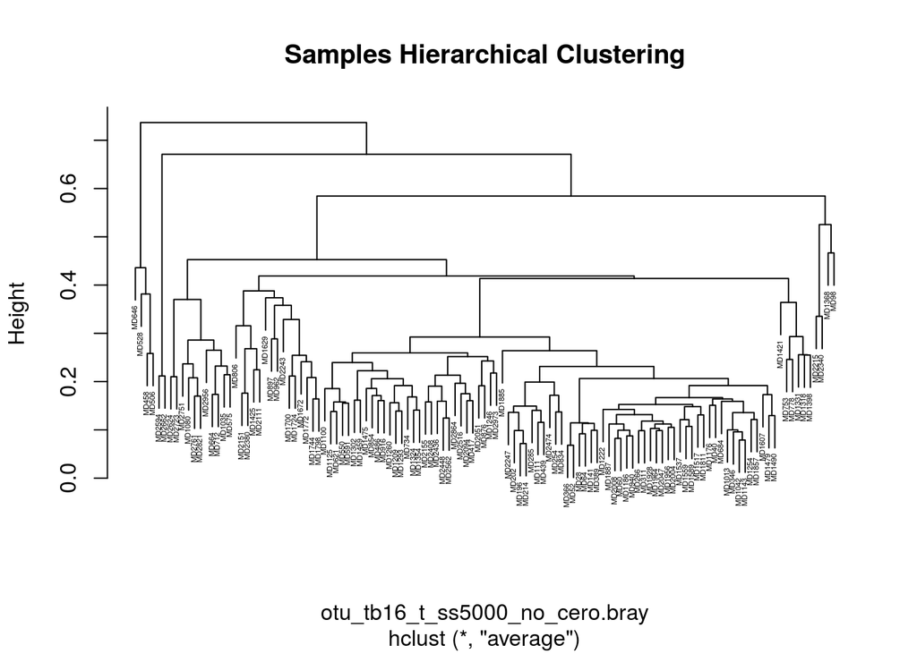

### 3.6.3) Non-metric multidimensional scaling

```
##
## Call:
## monoMDS(dist = otu_tb16_t_ss5000_no_cero.bray)
##
## Non-metric Multidimensional Scaling
##
## 119 points, dissimilarity 'bray', call 'vegdist(x = otu_tb16_t_ss5000_no_cero, method = "bray")'
##
## Dimensions: 2
## Stress:     0.1290503
## Stress type 1, weak ties
## Scores scaled to unit root mean square, rotated to principal components
## Stopped after 69 iterations: Stress nearly unchanged (ratio > sratmax)
```

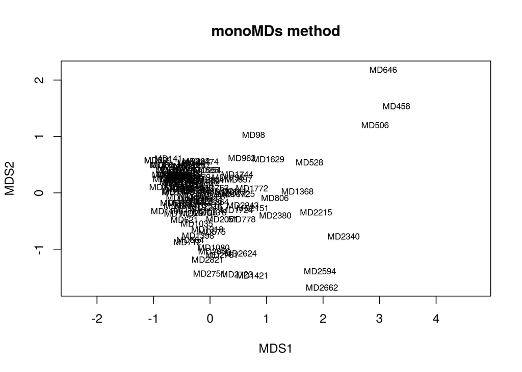

When implementing a most robut function for computing NMDS plots, the result is quiet the same:

```
## ... procrustes: rmse 0.02376693  max resid 0.1906279
## ... procrustes: rmse 0.008149484  max resid 0.07917848
## ... procrustes: rmse 0.006436317  max resid 0.06409706
```

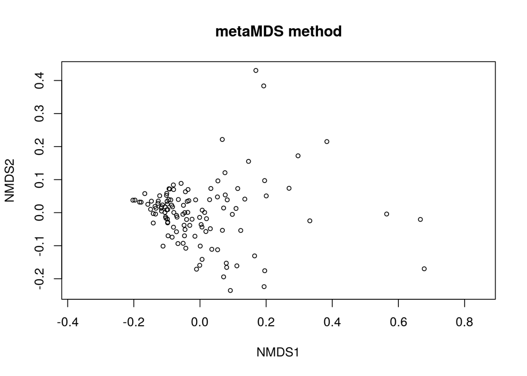

# 4) Geographical analysis

Working datasets:

1. Community matrix: otu_tb16_t_ss5000_no_cero

```r
dim(otu_tb16_t_ss5000_no_cero)
```

```
## [1]  119 1145
```

```r
otu_tb16_t_ss5000_no_cero[1:5, 1:5]
```

```
##        OTU_5 OTU_1 OTU_596 OTU_1295 OTU_36
## MD1013    34  2747       2        0      8
## MD1035    45  1545      11        1     34
## MD1042    37  2645       5        0     16
## MD1080    65   940      23        0     21
## MD1100    44  2102       3        0      3
```

2. Community Bray-Curtis: otu_tb16_t_ss5000_no_cero.bray

```r
otu_tb16_t_ss5000_no_cero.bray<-as.matrix(otu_tb16_t_ss5000_no_cero.bray)
```

3. Stations distances in km: geo_distances_MP_16S_ss5000

```r
dim(geo_distances_MP_16S_ss5000)
```

```
## [1] 119 119
```

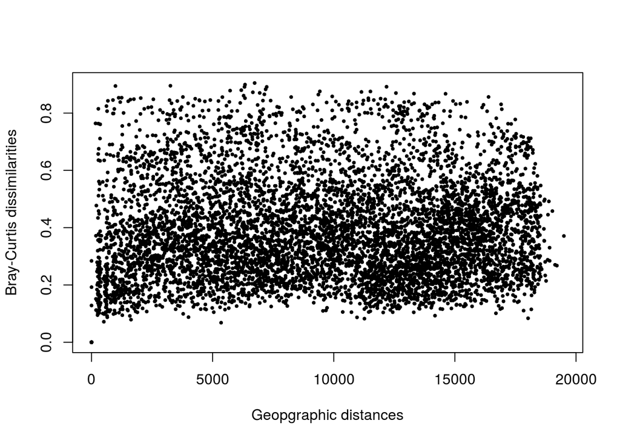

```r
plot(geo_distances_MP_16S_ss5000, otu_tb16_t_ss5000_no_cero.bray, pch=19, cex=0.4, xlab="Geopgraphic distances", ylab="Bray-Curtis dissimilarities")
```

## 4.1) Mantel correlograms

Mantel statistic is so low, meaning that the correlation between samples dissimilarity and geographical distances is weak; besides, it is not significant, so we shouldn’t consider the test meaningful.

```r
mantel(geo_distances_MP_16S_ss5000, otu_tb16_t_ss5000_no_cero.bray)
```

```
##
## Mantel statistic based on Pearson's product-moment correlation
##
## Call:
## mantel(xdis = geo_distances_MP_16S_ss5000, ydis = otu_tb16_t_ss5000_no_cero.bray)
##
## Mantel statistic r: 0.01761
##       Significance: 0.149
##
## Upper quantiles of permutations (null model):
##    90%    95%  97.5%    99%
## 0.0223 0.0283 0.0357 0.0430
## Permutation: free
## Number of permutations: 999
```

Maximum distance between samples:

```
## [1] 19500.19
```

Minimum distance between samples:

```
## [1] 0
```

Correlograms:

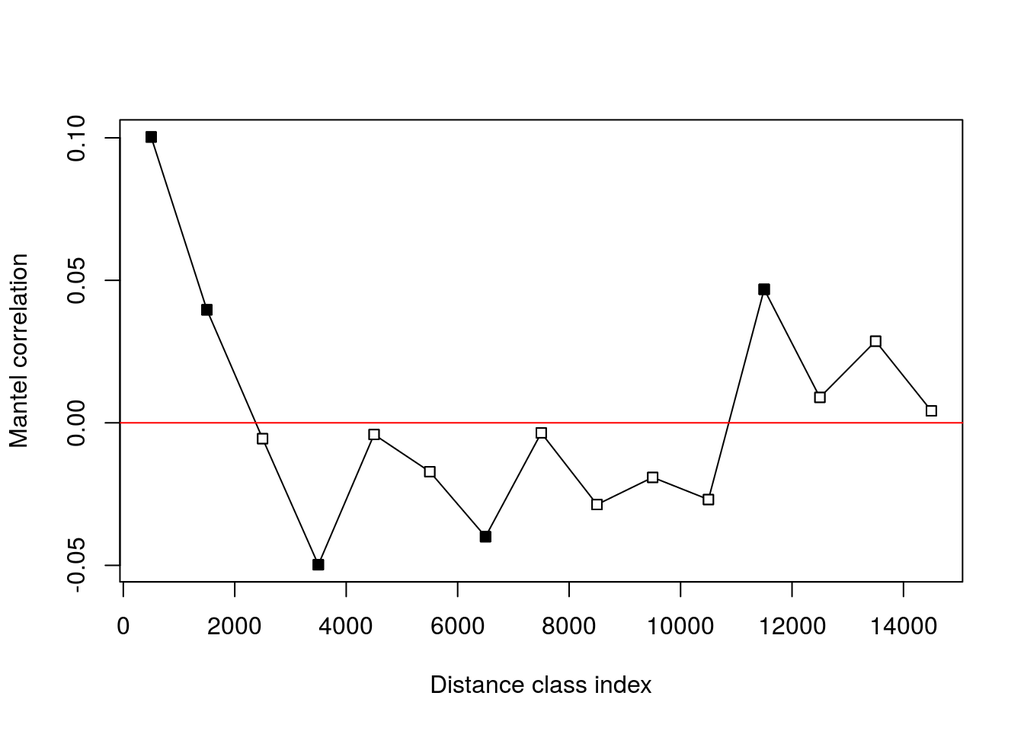

```r
MP_16s_ss5000_mantel_correl_by_1000km<-mantel.correlog(otu_tb16_t_ss5000_no_cero.bray, D.geo=geo_distances_MP_16S_ss5000, break.pts=seq(0,20000, by=1000))
plot(MP_16s_ss5000_mantel_correl_by_1000km)
```

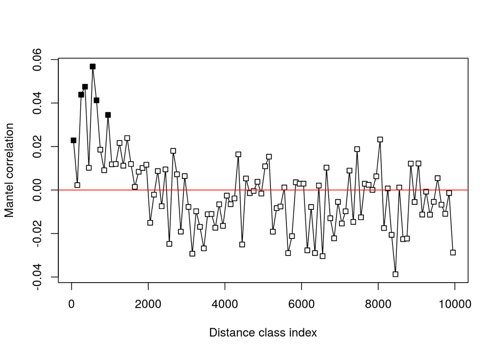

```r
MP_16s_ss5000_mantel_correl_by_100km<-mantel.correlog(otu_tb16_t_ss5000_no_cero.bray, D.geo=geo_distances_MP_16S_ss5000, break.pts=seq(0,20000, by=100))
plot(MP_16s_ss5000_mantel_correl_by_100km)
```